# Hausarbeit Maschinelles Lernen MADS23oB Heidi Gehring, Lea Kleemann

## Regression

```python
predictionmodelpath=models_path.joinpath('prediction_models')
```

```python
modela=svm.SVR(max_iter=150)
paramsa={'kernel':['linear','poly','rbf','sigmoid'],
         'degree':[3,4],
         'gamma':['auto','scale'],
         'coef0':[0.0,0.5,1],
         'tol':[0.001,0.003,0.01],
         'C':[1.0,0.5,2.0],
         'epsilon':[0.1,0.5],
         'shrinking':[True,False]
         }
grida=GridSearchCV(modela,paramsa,n_jobs=-1,cv=5,return_train_score=True)

modelb=DecisionTreeRegressor(random_state=randomstate)
paramsb={'criterion':['squared_error','friedman_mse','absolute_error','poisson'],
         'splitter':['best','random'],
         'max_depth':[None,5,10],
         'min_samples_split':[2,25,100],
         'min_samples_leaf':[1,100,50],
         'max_features':[None,'log2',5],
         'max_leaf_nodes':[None,10,20],
         'ccp_alpha':[0.0,0.2,0.5]
         }
gridb=GridSearchCV(modelb,paramsb,n_jobs=-1,cv=5,return_train_score=True)
```

```python
retrain_svr=True
retrain_regtree=True
if retrain_svr:
    regsvmmodel=grida.fit(xtrain,ytrain)
    joblib.dump(regsvmmodel,predictionmodelpath.joinpath('regsvmmodel.pkl').as_posix())
else:
    regsvmmodel=joblib.load(predictionmodelpath.joinpath('regsvmmodel.pkl').as_posix())
if retrain_regtree:
    regdtmodel=gridb.fit(xtrain,ytrain)
    joblib.dump(regdtmodel,predictionmodelpath.joinpath('regdtmodel.pkl').as_posix())
else:
    regdtmodel=joblib.load(predictionmodelpath.joinpath('regdtmodel.pkl').as_posix())
```

## Classification

```python
modelc=SVC(max_iter=150,random_state=randomstate)
paramsc={
    'C':[1.0,0.5,2.0],
    'kernel':['linear','poly','rbf','sigmoid'],
    'degree':[3,4],
    'gamma':['auto','scale'],
    'coef0':[0.0,0.5,1],
    'tol':[0.001,0.003,0.01],
    'shrinking':[True,False],
    'decision_function_shape':['ovo','ovr']
}
gridc=GridSearchCV(modelc,paramsc,n_jobs=-1,cv=5,return_train_score=True)

modeld=DecisionTreeClassifier(random_state=randomstate)
paramsd={
    'criterion':['gini','entropy','log_loss'],
    'splitter':['best','random'],
    'max_depth':[None,5,10],
    'min_samples_split':[2,25,100],
    'min_samples_leaf':[1,100,50],
    'max_features':[None,'log2',5],
    'max_leaf_nodes':[None,10,20],
    'ccp_alpha':[0.0,0.2,0.5]
}
gridd=GridSearchCV(modeld,paramsd,n_jobs=-1,cv=5,return_train_score=True)
```

```python
retrain_svm=True # runs vergy long, reload model as default, maybe use scaler
retrain_clastree=True
if retrain_svm:
    classvmmodel=gridc.fit(xtrain,ytrain)
    joblib.dump(classvmmodel,predictionmodelpath.joinpath('classsvmmodel.pkl').as_posix())
else:
    classvmmodel=joblib.load(predictionmodelpath.joinpath('classsvmmodel.pkl').as_posix())

if retrain_clastree:
    clasdtmodel=gridd.fit(xtrain,ytrain)
    joblib.dump(clasdtmodel,predictionmodelpath.joinpath('clasdtmodel.pkl').as_posix())
else:
    clasdtmodel=joblib.load(predictionmodelpath.joinpath('clasdtmodel.pkl').as_posix())
```

### evaluate models

```python
predregsvm=regsvmmodel.predict(xtest)
predregdt=regdtmodel.predict(xtest)

msesvm=mean_squared_error(ytest,predregsvm)
msedt=mean_squared_error(ytest,predregdt)
r2svm=r2_score(ytest,predregsvm)
r2dt=r2_score(ytest,predregdt)
```

```python
print(f'MSE SVM: {msesvm}, MSE DT: {msedt}')
print(f'R2 SVM: {r2svm}, R2 DT: {r2dt}')
```

```
MSE SVM: 1.3435918308909056, MSE DT: 1.0309330023640264
R2 SVM: -0.20169662014646916, R2 DT: 0.07794266379482506
```

```python
predclassvm=classvmmodel.predict(xtest)
predclasdt=clasdtmodel.predict(xtest)

accsvm=accuracy_score(ytest,predclassvm)
accdt=accuracy_score(ytest,predclasdt)
msesvm2=mean_squared_error(ytest,predclassvm)
msedt2=mean_squared_error(ytest,predclasdt)
```

```python
print(f'Accuracy SVM: {accsvm}, Accuracy DT: {accdt}') # the accuracy is not good, models might only predict a rating of 4 or 5 (unbalanced classes)
print(f'MSE SVM: {msesvm2}, MSE DT: {msedt2}')
```

```
Accuracy SVM: 0.3398890569843671, Accuracy DT: 0.37065052950075644
MSE SVM: 2.017650025214322, MSE DT: 1.312657589510842
```

## Regression and Classification NN

```python
retrain_studyregression=True
xtrain,xtest,ytrain,ytest=train_test_split(datadf.drop(['Actual Rating'],axis=1),datadf['Actual Rating'],test_size=0.1,random_state=randomstate,shuffle=True)
xtrain,xtest,ytrain,ytest=xtrain.reset_index(drop=True),xtest.reset_index(drop=True),ytrain.reset_index(drop=True),ytest.reset_index(drop=True) #kf.split() needs reset index; if drop=False, wird index zu neuer Spalte
studyname='prediction_regression'
thismodelpath=models_path.joinpath(f'{studyname}')
try:
    thismodelpath.mkdir(exist_ok=False)
except FileExistsError:
    print('Directory already exists')

if retrain_studyregression:
    def init_regmodel(trial):
        # model definition
        nlayers=trial.suggest_int('n_layers',1,10)
        model=tf.keras.Sequential()
        activation=trial.suggest_categorical('activation',['relu','tanh','sigmoid'])
        inputshape=xtrain.shape[1]
        model.add(tf.keras.layers.Dense(16, input_shape=(inputshape,),activation=activation))
        for i in range(nlayers):
            numhidden=trial.suggest_int(f'n_units_l{i}',32,128,log=True)
            model.add(tf.keras.layers.Dense(units=numhidden,activation=activation,name=f'layer{i}'))
        model.add(tf.keras.layers.Dense(units=1,activation='linear'))
        model.compile(optimizer='adam', loss='mean_absolute_error', metrics=['mean_squared_error'])
        return model

    def reg_objective(trial:Trial,xtrain:pd.DataFrame,ytrain:pd.Series)->float:
        kf = KFold(n_splits=5, shuffle=True, random_state=randomstate)
        model=init_regmodel(trial)
        # training and evaluation
        msetest=[]
        for train,test in kf.split(xtrain):
            trdata=tf.convert_to_tensor(xtrain.loc[train])
            trlabel=tf.convert_to_tensor(ytrain.loc[train])
            evdata=tf.convert_to_tensor(xtrain.loc[test])
            evlabel=tf.convert_to_tensor(ytrain.loc[test])

            model.fit(trdata,trlabel,validation_split=0.1,epochs=10, batch_size=128,verbose=0) #more verbosity seems to crash in execution

            loss,mse=model.evaluate(evdata, evlabel)
            # predtrain=tmodel.predict(evdata)
            # mse=tf.keras.losses.MSE(evlabel, predtrain)
            msetest.append(mse)

        return np.mean(msetest)

    storage=thismodelpath.joinpath(f"{studyname}.db")
    if storage.exists():
        storage.unlink()
    else:
        print("No sqlite db found")

    study=create_study(study_name=studyname,direction='minimize',storage=f'sqlite:///{storage.as_posix()}',load_if_exists=False)
    study.optimize(lambda trial: reg_objective(trial,xtrain,ytrain),n_trials=20,n_jobs=-1,show_progress_bar=True)

    joblib.dump(study,thismodelpath.joinpath(f'study_{study.study_name}.pkl').as_posix())

    regmodel = init_regmodel(study.best_trial)
    regmodel.fit(tf.convert_to_tensor(xtrain),tf.convert_to_tensor(ytrain),validation_split=0.1,epochs=10, batch_size=128,verbose=0)
    regmodel.save(thismodelpath.joinpath(f'fmodel_reg.h5').as_posix())

else:
    regmodel = tf.keras.models.load_model(thismodelpath.joinpath(f'fmodel_reg.h5').as_posix())
```

```
Directory already exists
```

```
[I 2024-09-08 17:36:41,168] A new study created in RDB with name: prediction_regression
```

```
[I 2024-09-08 17:38:20,996] Trial 11 finished with value: 1.0983523607254029 and parameters: {'n_layers': 1, 'activation': 'tanh', 'n_units_l0': 72}. Best is trial 11 with value: 1.0983523607254029.
```

```
[I 2024-09-08 17:38:25,275] Trial 9 finished with value: 1.1035995483398438 and parameters: {'n_layers': 2, 'activation': 'sigmoid', 'n_units_l0': 43, 'n_units_l1': 39}. Best is trial 11 with value: 1.0983523607254029.
```

```
[I 2024-09-08 17:38:27,630] Trial 6 finished with value: 1.1082559823989868 and parameters: {'n_layers': 3, 'activation': 'sigmoid', 'n_units_l0': 71, 'n_units_l1': 60, 'n_units_l2': 85}. Best is trial 11 with value: 1.0983523607254029.
```

```
[I 2024-09-08 17:38:27,937] Trial 1 finished with value: 1.1032121181488037 and parameters: {'n_layers': 3, 'activation': 'sigmoid', 'n_units_l0': 91, 'n_units_l1': 96, 'n_units_l2': 108}. Best is trial 11 with value: 1.0983523607254029.
```

```
[I 2024-09-08 17:38:30,694] Trial 7 finished with value: 1.1052340030670167 and parameters: {'n_layers': 1, 'activation': 'tanh', 'n_units_l0': 118}. Best is trial 11 with value: 1.0983523607254029.
```

```
[I 2024-09-08 17:38:31,590] Trial 3 finished with value: 1.103497052192688 and parameters: {'n_layers': 1, 'activation': 'sigmoid', 'n_units_l0': 41}. Best is trial 11 with value: 1.0983523607254029.
```

```
[I 2024-09-08 17:38:32,390] Trial 2 finished with value: 1.1015496969223022 and parameters: {'n_layers': 6, 'activation': 'tanh', 'n_units_l0': 85, 'n_units_l1': 102, 'n_units_l2': 74, 'n_units_l3': 73, 'n_units_l4': 70, 'n_units_l5': 54}. Best is trial 11 with value: 1.0983523607254029.
```

```
[I 2024-09-08 17:38:33,141] Trial 0 finished with value: 62.26049807071686 and parameters: {'n_layers': 4, 'activation': 'relu', 'n_units_l0': 72, 'n_units_l1': 48, 'n_units_l2': 36, 'n_units_l3': 48}. Best is trial 11 with value: 1.0983523607254029.
```

```
[I 2024-09-08 17:38:34,431] Trial 4 finished with value: 1.102556324005127 and parameters: {'n_layers': 6, 'activation': 'sigmoid', 'n_units_l0': 46, 'n_units_l1': 100, 'n_units_l2': 33, 'n_units_l3': 98, 'n_units_l4': 54, 'n_units_l5': 55}. Best is trial 11 with value: 1.0983523607254029.
```

```
[I 2024-09-08 17:38:34,741] Trial 15 finished with value: 33367.90241394043 and parameters: {'n_layers': 2, 'activation': 'relu', 'n_units_l0': 59, 'n_units_l1': 122}. Best is trial 11 with value: 1.0983523607254029.
```

```
[I 2024-09-08 17:38:34,763] Trial 12 finished with value: 1.1054610013961792 and parameters: {'n_layers': 4, 'activation': 'tanh', 'n_units_l0': 90, 'n_units_l1': 60, 'n_units_l2': 128, 'n_units_l3': 123}. Best is trial 11 with value: 1.0983523607254029.
```

```
[I 2024-09-08 17:38:36,591] Trial 8 finished with value: 1.1028719663619995 and parameters: {'n_layers': 5, 'activation': 'tanh', 'n_units_l0': 40, 'n_units_l1': 39, 'n_units_l2': 123, 'n_units_l3': 93, 'n_units_l4': 57}. Best is trial 11 with value: 1.0983523607254029.
```

```
[I 2024-09-08 17:38:36,914] Trial 14 finished with value: 1.1038359880447388 and parameters: {'n_layers': 8, 'activation': 'sigmoid', 'n_units_l0': 41, 'n_units_l1': 56, 'n_units_l2': 53, 'n_units_l3': 34, 'n_units_l4': 34, 'n_units_l5': 38, 'n_units_l6': 51, 'n_units_l7': 37}. Best is trial 11 with…
```

```
[I 2024-09-08 17:38:38,635] Trial 5 finished with value: 1.1150514841079713 and parameters: {'n_layers': 10, 'activation': 'relu', 'n_units_l0': 115, 'n_units_l1': 35, 'n_units_l2': 43, 'n_units_l3': 69, 'n_units_l4': 77, 'n_units_l5': 41, 'n_units_l6': 96, 'n_units_l7': 89, 'n_units_l8': 120, 'n_un…
```

```
[I 2024-09-08 17:38:38,671] Trial 13 finished with value: 1.0992093324661254 and parameters: {'n_layers': 10, 'activation': 'sigmoid', 'n_units_l0': 46, 'n_units_l1': 99, 'n_units_l2': 61, 'n_units_l3': 40, 'n_units_l4': 68, 'n_units_l5': 116, 'n_units_l6': 112, 'n_units_l7': 77, 'n_units_l8': 108, …
```

```
[I 2024-09-08 17:38:54,372] Trial 16 finished with value: 547.3403930664062 and parameters: {'n_layers': 2, 'activation': 'relu', 'n_units_l0': 66, 'n_units_l1': 82}. Best is trial 11 with value: 1.0983523607254029.
```

```
[I 2024-09-08 17:38:57,606] Trial 19 finished with value: 1.1043873310089112 and parameters: {'n_layers': 3, 'activation': 'sigmoid', 'n_units_l0': 74, 'n_units_l1': 56, 'n_units_l2': 55}. Best is trial 11 with value: 1.0983523607254029.
```

```
[I 2024-09-08 17:39:01,734] Trial 17 finished with value: 2.868753504753113 and parameters: {'n_layers': 6, 'activation': 'relu', 'n_units_l0': 127, 'n_units_l1': 67, 'n_units_l2': 107, 'n_units_l3': 66, 'n_units_l4': 53, 'n_units_l5': 35}. Best is trial 11 with value: 1.0983523607254029.
```

```
[I 2024-09-08 17:39:03,653] Trial 18 finished with value: 2.528973126411438 and parameters: {'n_layers': 7, 'activation': 'relu', 'n_units_l0': 86, 'n_units_l1': 83, 'n_units_l2': 111, 'n_units_l3': 53, 'n_units_l4': 84, 'n_units_l5': 34, 'n_units_l6': 32}. Best is trial 11 with value: 1.09835236072…
```

```python
retrain_studyclassification=True
xtrain,xtest,ytrain,ytest=train_test_split(datadf.drop(['Actual Rating'],axis=1),datadf['Actual Rating'],test_size=0.1,random_state=randomstate,shuffle=True)
xtrain,xtest,ytrain,ytest=xtrain.reset_index(drop=True),xtest.reset_index(drop=True),ytrain.reset_index(drop=True),ytest.reset_index(drop=True)

studyname='prediction_classification'
thismodelpath=models_path.joinpath(f'{studyname}')
try:
    thismodelpath.mkdir(exist_ok=False)
except FileExistsError:
    print('Directory already exists')
if retrain_studyclassification:
    def init_clasmodel(trial):
        # model definition
        nlayers=trial.suggest_int('n_layers',1,10)
        model=tf.keras.Sequential()
        activation=trial.suggest_categorical('activation',['relu','tanh','sigmoid'])
        inputshape=xtrain.shape[1]
        model.add(tf.keras.layers.Dense(16, input_shape=(inputshape,),activation=activation))
        for i in range(nlayers):
            numhidden=trial.suggest_int(f'n_units_l{i}',32,128,log=True)
            model.add(tf.keras.layers.Dense(units=numhidden,activation=activation,name=f'layer{i}'))
        model.add(tf.keras.layers.Dense(units=5,activation='softmax'))
        model.compile(optimizer='adam', loss='categorical_crossentropy', metrics=['accuracy'])
        return model

    def clas_objective(trial:Trial,xtrain:pd.DataFrame,ytrain:pd.Series)->float:
        kf = KFold(n_splits=5, shuffle=True, random_state=randomstate)
        ytrain=datadf['Actual Rating'].apply(lambda x: x-1)
        model=init_clasmodel(trial)
        # training and evaluation
        acctest=[]
        for train,test in kf.split(xtrain):
            trdata=tf.convert_to_tensor(xtrain.loc[train])
            trlabel=tf.convert_to_tensor(tf.keras.utils.to_categorical(ytrain.loc[train],num_classes=5))
            evdata=tf.convert_to_tensor(xtrain.loc[test])
            evlabel=tf.convert_to_tensor(tf.keras.utils.to_categorical(ytrain.loc[test],num_classes=5))

            model.fit(trdata,trlabel,validation_split=0.1,epochs=10, batch_size=128,verbose=0) #more verbosity seems to crash in execution

            loss,acc=model.evaluate(evdata, evlabel)
            # predtrain=tmodel.predict(evdata)
            # mse=tf.keras.losses.MSE(evlabel, predtrain)
            acctest.append(acc)

        return np.mean(acctest)

    storage=thismodelpath.joinpath(f"{studyname}.db")
    if storage.exists():
        storage.unlink()
    else:
        print("No sqlite db found")

    study=create_study(study_name=studyname,direction='maximize',storage=f'sqlite:///{storage.as_posix()}',load_if_exists=False)
    study.optimize(lambda trial: clas_objective(trial,xtrain,ytrain),n_trials=20,n_jobs=-1,show_progress_bar=True)

    joblib.dump(study,thismodelpath.joinpath(f'study_{study.study_name}.pkl').as_posix())

    classmodel = init_clasmodel(study.best_trial)
    ytrain=datadf['Actual Rating'].apply(lambda x: x-1)
    classmodel.fit(tf.convert_to_tensor(xtrain),tf.convert_to_tensor(tf.keras.utils.to_categorical(ytrain,num_classes=5)),validation_split=0.1,epochs=10, batch_size=128,verbose=0)
    classmodel.save(thismodelpath.joinpath(f'fmodel_clas.h5').as_posix())
else:
    classmodel=tf.keras.models.load_model(thismodelpath.joinpath(f'fmodel_clas.h5').as_posix())
```

```
[I 2024-09-08 17:39:06,429] A new study created in RDB with name: prediction_classification
```

```
Directory already exists
```

```
[I 2024-09-08 17:41:00,991] Trial 2 finished with value: 0.3394433677196503 and parameters: {'n_layers': 2, 'activation': 'sigmoid', 'n_units_l0': 65, 'n_units_l1': 105}. Best is trial 2 with value: 0.3394433677196503.
```

```
[I 2024-09-08 17:41:06,491] Trial 9 finished with value: 0.3441506624221802 and parameters: {'n_layers': 1, 'activation': 'tanh', 'n_units_l0': 63}. Best is trial 9 with value: 0.3441506624221802.
```

```
[I 2024-09-08 17:41:09,201] Trial 1 finished with value: 0.31097409725189207 and parameters: {'n_layers': 5, 'activation': 'relu', 'n_units_l0': 68, 'n_units_l1': 109, 'n_units_l2': 58, 'n_units_l3': 35, 'n_units_l4': 67}. Best is trial 9 with value: 0.3441506624221802.
```

```
[I 2024-09-08 17:41:15,491] Trial 3 finished with value: 0.3508210301399231 and parameters: {'n_layers': 5, 'activation': 'sigmoid', 'n_units_l0': 47, 'n_units_l1': 72, 'n_units_l2': 93, 'n_units_l3': 85, 'n_units_l4': 37}. Best is trial 3 with value: 0.3508210301399231.
```

```
[I 2024-09-08 17:41:16,478] Trial 4 finished with value: 0.3429760754108429 and parameters: {'n_layers': 8, 'activation': 'relu', 'n_units_l0': 96, 'n_units_l1': 72, 'n_units_l2': 126, 'n_units_l3': 44, 'n_units_l4': 120, 'n_units_l5': 105, 'n_units_l6': 41, 'n_units_l7': 48}. Best is trial 3 with v…
```

```
[I 2024-09-08 17:41:17,076] Trial 15 finished with value: 0.3508210301399231 and parameters: {'n_layers': 5, 'activation': 'tanh', 'n_units_l0': 53, 'n_units_l1': 52, 'n_units_l2': 39, 'n_units_l3': 56, 'n_units_l4': 126}. Best is trial 3 with value: 0.3508210301399231.
```

```
[I 2024-09-08 17:41:17,752] Trial 11 finished with value: 0.3487470388412476 and parameters: {'n_layers': 6, 'activation': 'sigmoid', 'n_units_l0': 44, 'n_units_l1': 93, 'n_units_l2': 51, 'n_units_l3': 93, 'n_units_l4': 108, 'n_units_l5': 33}. Best is trial 3 with value: 0.3508210301399231.
```

```
[I 2024-09-08 17:41:18,578] Trial 12 finished with value: 0.3160767912864685 and parameters: {'n_layers': 6, 'activation': 'relu', 'n_units_l0': 33, 'n_units_l1': 116, 'n_units_l2': 47, 'n_units_l3': 88, 'n_units_l4': 106, 'n_units_l5': 36}. Best is trial 3 with value: 0.3508210301399231.
```

```
[I 2024-09-08 17:41:19,774] Trial 10 finished with value: 0.3440399765968323 and parameters: {'n_layers': 8, 'activation': 'tanh', 'n_units_l0': 71, 'n_units_l1': 37, 'n_units_l2': 120, 'n_units_l3': 93, 'n_units_l4': 116, 'n_units_l5': 91, 'n_units_l6': 123, 'n_units_l7': 43}. Best is trial 3 with …
```

```
[I 2024-09-08 17:41:19,831] Trial 0 finished with value: 0.34330981969833374 and parameters: {'n_layers': 9, 'activation': 'sigmoid', 'n_units_l0': 49, 'n_units_l1': 49, 'n_units_l2': 96, 'n_units_l3': 36, 'n_units_l4': 84, 'n_units_l5': 33, 'n_units_l6': 34, 'n_units_l7': 81, 'n_units_l8': 127}. Be…
```

```
[I 2024-09-08 17:41:20,431] Trial 5 finished with value: 0.350036495923996 and parameters: {'n_layers': 10, 'activation': 'relu', 'n_units_l0': 59, 'n_units_l1': 45, 'n_units_l2': 69, 'n_units_l3': 70, 'n_units_l4': 71, 'n_units_l5': 112, 'n_units_l6': 45, 'n_units_l7': 114, 'n_units_l8': 47, 'n_uni…
```

```
[I 2024-09-08 17:41:37,428] Trial 17 finished with value: 0.34291741251945496 and parameters: {'n_layers': 3, 'activation': 'tanh', 'n_units_l0': 83, 'n_units_l1': 32, 'n_units_l2': 73}. Best is trial 3 with value: 0.3508210301399231.
```

```
[I 2024-09-08 17:41:37,956] Trial 19 finished with value: 0.34566410183906554 and parameters: {'n_layers': 2, 'activation': 'tanh', 'n_units_l0': 37, 'n_units_l1': 38}. Best is trial 3 with value: 0.3508210301399231.
```

```
[I 2024-09-08 17:41:39,753] Trial 16 finished with value: 0.33832228779792783 and parameters: {'n_layers': 5, 'activation': 'sigmoid', 'n_units_l0': 64, 'n_units_l1': 62, 'n_units_l2': 45, 'n_units_l3': 100, 'n_units_l4': 98}. Best is trial 3 with value: 0.3508210301399231.
```

```
[I 2024-09-08 17:41:40,820] Trial 18 finished with value: 0.3410677373409271 and parameters: {'n_layers': 7, 'activation': 'relu', 'n_units_l0': 40, 'n_units_l1': 94, 'n_units_l2': 77, 'n_units_l3': 55, 'n_units_l4': 41, 'n_units_l5': 49, 'n_units_l6': 35}. Best is trial 3 with value: 0.350821030139…
```

## Compare models to Predicted Rating

```python
datadf=pd.read_csv(datawreviewsfile,sep=';')
# fulldatadf=pd.read_csv(dataworeviewsfile,sep=';')
datadf=datadf.drop(['biography', 'children', 'comics', 'crime', 'fantasy', 'fiction',
       'graphic', 'historicalfiction', 'history', 'mystery', 'nonfiction',
       'paranormal', 'poetry', 'romance', 'thriller', 'youngadult'],axis=1)

def remove_punctuation(x):
    cleanedtext=re.sub('[^A-Za-z0-9]+', ' ', x)
    return cleanedtext
datadf['description']=datadf.description.transform(remove_punctuation)
datadf['genre']=datadf.genre.apply(lambda x: x.replace("'","")) # remove '
datadf['genre']=datadf.genre.apply(lambda x: x.replace("-","")) # revome -
datadf['genre']=datadf.genre.apply(lambda x: x.replace(" ","")) # remove spaces
datadf['genre']=datadf.genre.apply(lambda x: x[1:-1].split(',')) # split into list

mlbmodelpath=models_path.joinpath('mlb_model')
mlbmodel=joblib.load(mlbmodelpath.joinpath('mlbmodel.pkl').as_posix())
newcols=mlbmodel.classes_
pred=mlbmodel.transform(datadf.genre)
preddf=pd.DataFrame(pred,columns=newcols)
datadf=datadf.join(preddf)

descriptionmodelpath=models_path.joinpath('description_models')
descmodel=joblib.load(descriptionmodelpath.joinpath('gridamodel.pkl').as_posix())
newcols=descmodel.best_estimator_.named_steps['lda'].get_feature_names_out()
pred=descmodel.best_estimator_.transform(datadf.description)
preddf=pd.DataFrame(pred,columns=newcols)
datadf=datadf.join(preddf)

x=datadf[['user_id_mapping', 'num_pages',
       'ratings_count', 'biography', 'children', 'comics', 'crime', 'fantasy',
       'fiction', 'graphic', 'historicalfiction', 'history', 'mystery',
       'nonfiction', 'paranormal', 'poetry', 'romance', 'thriller',
       'youngadult', 'latentdirichletallocation0',
       'latentdirichletallocation1', 'latentdirichletallocation2']]
y=datadf[['Predicted Rating', 'Actual Rating',]]

def get_class_pred(x):
    pred=classmodel.predict(tf.convert_to_tensor(x))
    classpred=[]
    for x in pred:
        classpred.append(np.argmax(x)+1)
    return classpred
```

```python
y['regsvm']=regsvmmodel.best_estimator_.predict(x)
y['regdt']=regdtmodel.best_estimator_.predict(x)
y['classvm']=classvmmodel.best_estimator_.predict(x)
y['clasdt']=clasdtmodel.best_estimator_.predict(x)
y['regmodel']=regmodel.predict(tf.convert_to_tensor(x))
y['clasmodel']=get_class_pred(x)
```

```python
baseline=mean_squared_error(y['Actual Rating'],y['Predicted Rating'])
regsvmscore=mean_squared_error(y['Actual Rating'],y['regsvm'])
regtdtscore=mean_squared_error(y['Actual Rating'],y['regdt'])
classvmscore=mean_squared_error(y['Actual Rating'],y['classvm'])
clasdtscore=mean_squared_error(y['Actual Rating'],y['clasdt'])
clasmodelscore=mean_squared_error(y['Actual Rating'],y['clasmodel'])
regmodelscore=mean_squared_error(y['Actual Rating'],y['regmodel'])
```

```python
# Print Mean Squared Error for each model
# --> some may only predicts 5*s, not robust models
print(f'MSE Predicted Rating: {baseline}')
print(f'MSE regsvm: {regsvmscore}')
print(f'MSE regdt: {regtdtscore}')
print(f'MSE classsvm: {classvmscore}')
print(f'MSE clasdt: {clasdtscore}')
print(f'MSE clasmodel: {clasmodelscore}')
print(f'MSE regmodel: {regmodelscore}')
```

```
MSE Predicted Rating: 0.7844668079096044
MSE regsvm: 1.3151504084807035
MSE regdt: 1.134421246139446
MSE classsvm: 2.0202784503631963
MSE clasdt: 1.4445621468926553
MSE clasmodel: 1.1058313155770783
MSE regmodel: 1.0991262770282197
```

- Comparing the trained models to the Predicted Rating included in the dataset, it is obvious that the model quality is lower than the one used by the dataset creator.
- Regression Trees seem to come the closest to the Predicted Rating (In previous runs (MSE: 0.9), not true anymore. Regression Neural Network is better now).
- SVR und SVM had major problems during training and weren't converging correctly. Scalers were suggested in the warnings and might have helped those issues. Time constraints did not allow for more fiddling with optimization.
- On average the prediction made by Regression models seems to have performed better. In the case of neural networks, the predictions seem of similar quality, so the path easiest to optimize and implement should be further optimized.
- The trained models include the user id of the reviewer as an input feature. This was determined to be unusable from the beginning, so confidence in the models was not high from the beginning. The user id was supposed to be exchanged for a representation of the users reading preferences created via clustering. As the clustering approaches proved non-conclusive in the time given, no replacement took place. Further analysis regarding representing the user by the books he enjoyed and didn't enjoy should take place. Averaging scores by genre or fuzzy clustering approaches could be evaluated.
- The reviews were unbalanced towards better scores, so boosting ensembles made from Regression models could prove more accurate
- It was determied that quite a bit more work could be put into preprocessing the data to observe the impact on the rating prediction
- A deep dive into the hyperparameters of models trained could prove helpful

## Prediction based on information about users that have rated

Starting with a more detailed analysis of the merged data set from the experiment to cluster users.

```python
# inspired by Leas approach to analyze the initial dataset

print(f"Number of observations: {len(merged_df)}")
print(f"Number of unique book ids: {len(merged_df['book_id_x'].unique())}")
print(f"Number of unique user ids: {len(merged_df['user_id_mapping'].unique())}")


#limiting the output to 2 decimal digits for average rating
print(f"Average actual rating: {merged_df['Actual Rating'].mean():.2f}")
print(f"Average predicted rating: {merged_df['Predicted Rating'].mean():.2f}")
```

```
Number of observations: 19824
Number of unique book ids: 95
Number of unique user ids: 17103
Average actual rating: 3.87
Average predicted rating: 3.86
```

```python
# max numnber of ratings per user and others
# groupby user id
merged_df_userids=merged_df[["user_id_mapping","book_id_x"]].groupby(by="user_id_mapping").count()
merged_df_userids=merged_df_userids.reset_index()
merged_df_userids=merged_df_userids.rename(columns={"book_id_x":"book_count"})
```

```python
print(f"(repeat) Number of users: {len(merged_df_userids)}")
print(f"Max number of books revied per user: {merged_df_userids.book_count.max()}")
print(f"Min number of books revied per user: {merged_df_userids.book_count.min()}")
print(f"Number of users with 1 review: {len(merged_df_userids.query('book_count == 1'))}")
print(f"... in %: {round(len(merged_df_userids.query('book_count == 1'))/len(merged_df_userids),2)*100}%")
print(f"Number of users with 2 review: {len(merged_df_userids.query('book_count == 2'))}")
print(f"... in %: {round(len(merged_df_userids.query('book_count == 2'))/len(merged_df_userids),2)*100}%")
print(f"Number of users with less than 3 reviews: {len(merged_df_userids.query('book_count < 3'))}")
print(f"... in %: {round(len(merged_df_userids.query('book_count < 3'))/len(merged_df_userids),2)*100}%")
print(f"Number of users with more than 1 review: {len(merged_df_userids.query('book_count >1'))}")
print(f"... in %: {len(merged_df_userids.query('book_count > 1')) / len(merged_df_userids) * 100:.2f}%")
```

```
(repeat) Number of users: 17103
Max number of books revied per user: 5
Min number of books revied per user: 1
Number of users with 1 review: 14668
... in %: 86.0%
Number of users with 2 review: 2181
... in %: 13.0%
Number of users with less than 3 reviews: 16849
... in %: 99.0%
Number of users with more than 1 review: 2435
... in %: 14.24%
```

```python
# group by the user IDs and count the entries per userid
id_counts = merged_df.groupby('user_id_mapping').size()
print(id_counts.head())
```

```
user_id_mapping
2     1
4     1
7     1
21    1
23    1
dtype: int64
```

For the prediction, use only the data of users that have 2 or more book ratings.

```python
# filter for user-ids with 2 or more entries

ids_with_multiple_entries = id_counts[id_counts >= 2].index

# Filter the original DataFrame to only include these IDs
df_filtered = merged_df[merged_df['user_id_mapping'].isin(ids_with_multiple_entries)]
print(ids_with_multiple_entries.shape)
print(df_filtered.shape)
```

```
(2435,)
(5156, 39)
```

```python
# more analyis
# max numnber of ratings per user and others
# groupby user id

df_filtered_userids=df_filtered[["user_id_mapping","book_id_x"]].groupby(by="user_id_mapping").count()
df_filtered_userids=df_filtered_userids.reset_index()
df_filtered_userids=df_filtered_userids.rename(columns={"book_id_x":"book_count"})
```

```python
#verifiying that now we have a dataframe where every user has reviewed at least 2 books
print(f"(repeat) Number of users: {len(df_filtered_userids)}")
print(f"Max number of books revied per user: {df_filtered_userids.book_count.max()}")
print(f"Min number of books revied per user: {df_filtered_userids.book_count.min()}")
```

```
(repeat) Number of users: 2435
Max number of books revied per user: 5
Min number of books revied per user: 2
```

A dataframe with 5156 lines with entries of 2435 users that have at least 2 ratings will be used for the predictions

```python
#Show information about the merged and grouped dataset

print(f"Number of users with more than 1 review: {len(df_filtered_userids.query('book_count >1'))}")
print(df_filtered_userids.columns)
print(df_filtered_userids.shape)
print(df_filtered.shape)
```

```
Number of users with more than 1 review: 2435
Index(['user_id_mapping', 'book_count'], dtype='object')
(2435, 2)
(5156, 39)
```

```python
print(df_filtered.columns)
```

```
Index(['title_x', 'book_id_x', 'user_id_mapping', 'book_id_mapping',
       'Predicted Rating', 'Actual Rating', 'book_id_y', 'title_y',
       'image_url', 'url', 'num_pages', 'ratings_count', 'description', 'name',
       ' biography', ' children', ' comics', ' crime', ' fantasy', ' fiction',
       ' graphic', ' historical fiction', ' history', ' mystery',
       ' nonfiction', ' paranormal', ' poetry', ' romance', ' thriller',
       ' youngadult', 'children', 'comics', 'fantasy', 'fiction', 'mystery',
       'nonfiction', 'poetry', 'romance', 'youngadult'],
      dtype='object')
```

```python
#remove columns that are not needed going forward, e.g with double entry and text only, that cannot be used in the algorithm
df_prediction = df_filtered.drop(['Predicted Rating', 'book_id_y', 'title_y', 'description', 'image_url', 'url', 'name'],axis=1 )
```

```python
#verify that  code did what it should do
print(df_prediction.columns)
```

```
Index(['title_x', 'book_id_x', 'user_id_mapping', 'book_id_mapping',
       'Actual Rating', 'num_pages', 'ratings_count', ' biography',
       ' children', ' comics', ' crime', ' fantasy', ' fiction', ' graphic',
       ' historical fiction', ' history', ' mystery', ' nonfiction',
       ' paranormal', ' poetry', ' romance', ' thriller', ' youngadult',
       'children', 'comics', 'fantasy', 'fiction', 'mystery', 'nonfiction',
       'poetry', 'romance', 'youngadult'],
      dtype='object')
```

```python
print(df_prediction.head())
print(df_prediction.shape)
```

```
                       title_x  book_id_x  user_id_mapping  book_id_mapping  \
1   We Should All Be Feminists   22738563            45548              873
4   We Should All Be Feminists   22738563            41888              873
10  We Should All Be Feminists   22738563            19426              873
13  We Should All Be Feminists   22738563            46744              873
14  We Should All Be Feminists   22738563            26977              873

    Actual Rating  num_pages  ratings_count   biography   children   comics  \
1               4       1007         151473           0          0        0
4               5       1007         151473           0          0        0
10              5       1007         151473           0          0        0
13              5       1007         151473           0          0        0
14              4       1007         151473           0          0        0

    ...   youngadult  children  comics  fantasy  fiction  mystery  nonfiction  \
1   ...            0         0       0        1        0        0           0
4   ...            0         0       0        1        0        0           0
10  ...            0         0       0        1        0        0           0
13  ...            0         0       0        1        0        0           0
14  ...            0         0       0        1        0        0           0

    poetry  romance  youngadult
1        0        0           0
4        0        0           0
10       0        0           0
13       0        0           0
14       0        0           0

[5 rows x 32 columns]
(5156, 32)
```

Before going into the prediction, based on what was discussed during the lecture on site in Hamburg, more visualization is prepared to help understand the data.

```python
# making the columns to feature to prepare prediction
# starting with all columns in the df are features
X = df_prediction.copy()  # Copy the DataFrame to preserve the original
print(X)
```

```
                               title_x  book_id_x  user_id_mapping  \
1           We Should All Be Feminists   22738563            45548
4           We Should All Be Feminists   22738563            41888
10          We Should All Be Feminists   22738563            19426
13          We Should All Be Feminists   22738563            46744
14          We Should All Be Feminists   22738563            26977
...                                ...        ...              ...
19816  The Wonderful Wizard of Oz Oz 1     236093             6263
19817  The Wonderful Wizard of Oz Oz 1     236093            27954
19818  The Wonderful Wizard of Oz Oz 1     236093            24286
19819  The Wonderful Wizard of Oz Oz 1     236093            16631
19822  The Wonderful Wizard of Oz Oz 1     236093             6029

       book_id_mapping  Actual Rating  num_pages  ratings_count   biography  \
1                  873              4       1007         151473           0
```

[output cut: 38 more lines]

```python
sns.set(font_scale=1)
sns.set_style('whitegrid')
```

```python
# Access the feature names
feature_names = df_prediction.columns.tolist()
print("Feature names:", feature_names)
```

```
Feature names: ['title_x', 'book_id_x', 'user_id_mapping', 'book_id_mapping', 'Actual Rating', 'num_pages', 'ratings_count', ' biography', ' children', ' comics', ' crime', ' fantasy', ' fiction', ' graphic', ' historical fiction', ' history', ' mystery', ' nonfiction', ' paranormal', ' poetry', ' r…
```

```python
# Adding the feature_names as an attribute to the DataFrame
df_prediction.feature_names = df_prediction.columns.tolist()

# Access the custom attribute
print("Feature names attribute:", df_prediction.feature_names)
```

```
Feature names attribute: ['title_x', 'book_id_x', 'user_id_mapping', 'book_id_mapping', 'Actual Rating', 'num_pages', 'ratings_count', ' biography', ' children', ' comics', ' crime', ' fantasy', ' fiction', ' graphic', ' historical fiction', ' history', ' mystery', ' nonfiction', ' paranormal', ' po…
```

```python
print(df_prediction.head())
```

```
                       title_x  book_id_x  user_id_mapping  book_id_mapping  \
1   We Should All Be Feminists   22738563            45548              873
4   We Should All Be Feminists   22738563            41888              873
10  We Should All Be Feminists   22738563            19426              873
13  We Should All Be Feminists   22738563            46744              873
14  We Should All Be Feminists   22738563            26977              873

    Actual Rating  num_pages  ratings_count   biography   children   comics  \
1               4       1007         151473           0          0        0
4               5       1007         151473           0          0        0
10              5       1007         151473           0          0        0
13              5       1007         151473           0          0        0
14              4       1007         151473           0          0        0

    ...   youngadult  children  comics  fantasy  fiction  mystery  nonfiction  \
1   ...            0         0       0        1        0        0           0
4   ...            0         0       0        1        0        0           0
10  ...            0         0       0        1        0        0           0
13  ...            0         0       0        1        0        0           0
14  ...            0         0       0        1        0        0           0

    poetry  romance  youngadult
1        0        0           0
4        0        0           0
10       0        0           0
13       0        0           0
14       0        0           0

[5 rows x 32 columns]
```

Plot the ratings (dependable variable) against each featuers (independent variable) to visualize potential patterns. Based on those plots, no patterns are visible.

Therefore it was decided to reduce the data to 1 vector per user again, to use this as input for prediction.

[figure not shown]

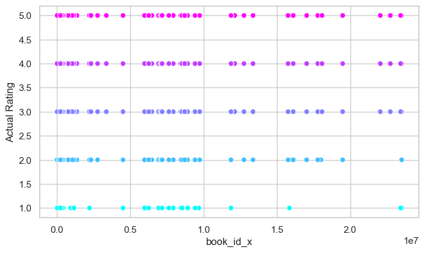

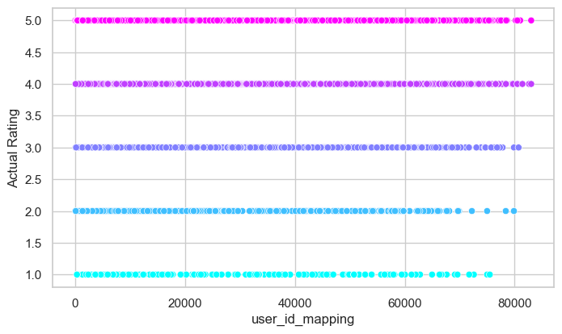

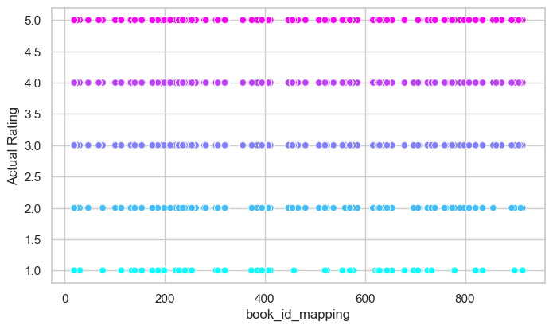

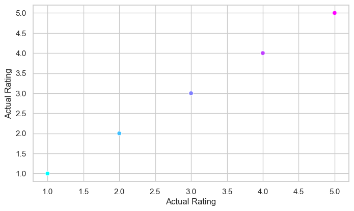

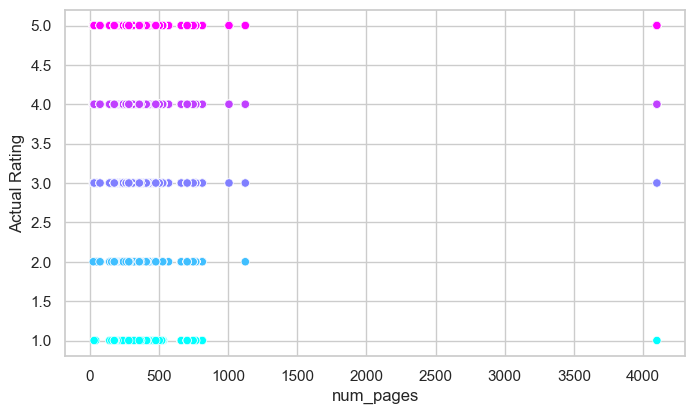

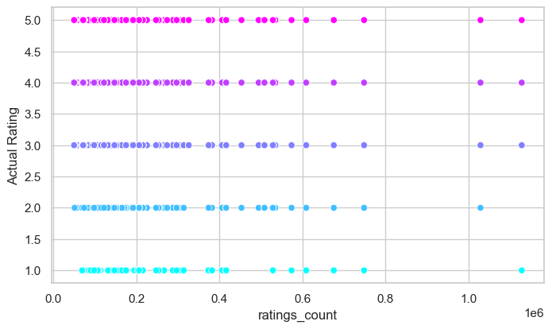

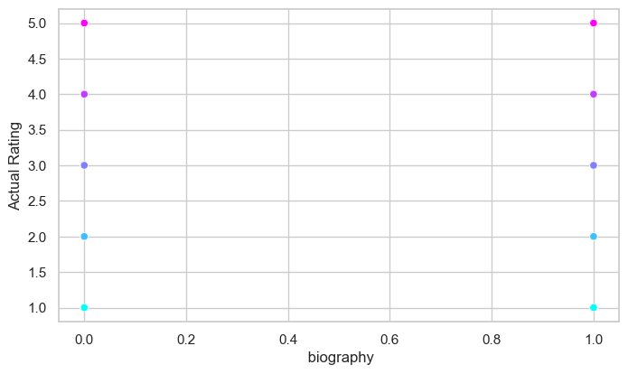

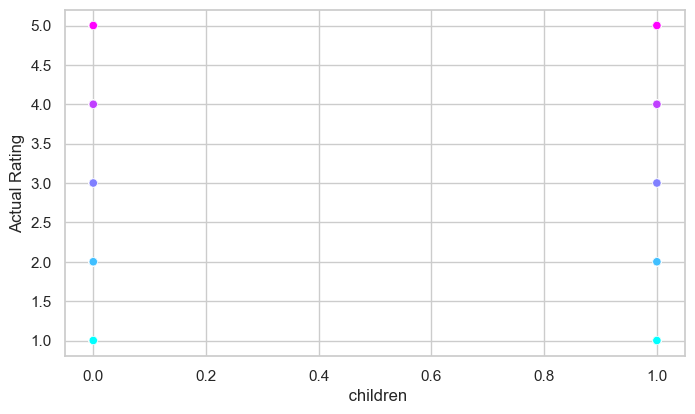

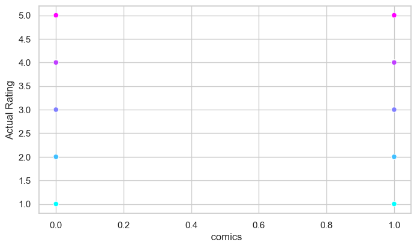

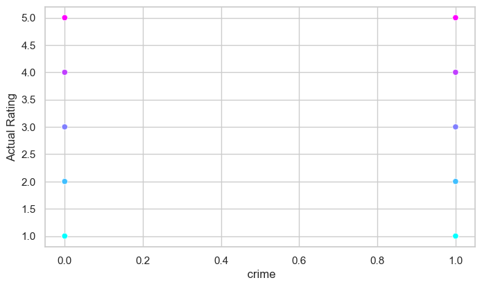

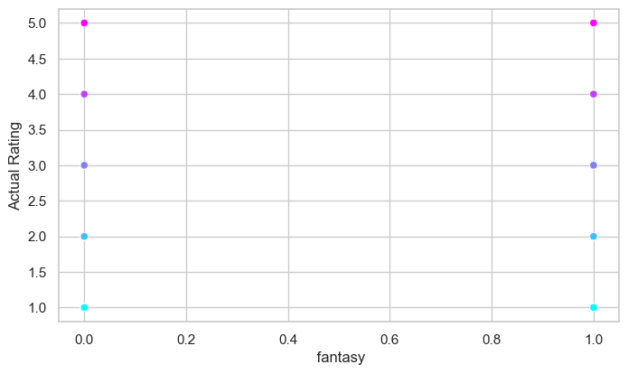

[20 more figures not shown]

```python
# plotting ratings against each feature
for feature in df_prediction.feature_names:
    plt.figure(figsize=(8, 4.5))  # 8"-by-4.5" Figure
    sns.scatterplot(data=df_prediction, x=feature,
                    y='Actual Rating', hue='Actual Rating',
                    palette='cool', legend=False)
```

```python
print(df_filtered.shape)
print(df_filtered.columns)
```

```
(5156, 39)
Index(['title_x', 'book_id_x', 'user_id_mapping', 'book_id_mapping',
       'Predicted Rating', 'Actual Rating', 'book_id_y', 'title_y',
       'image_url', 'url', 'num_pages', 'ratings_count', 'description', 'name',
       ' biography', ' children', ' comics', ' crime', ' fantasy', ' fiction',
       ' graphic', ' historical fiction', ' history', ' mystery',
       ' nonfiction', ' paranormal', ' poetry', ' romance', ' thriller',
       ' youngadult', 'children', 'comics', 'fantasy', 'fiction', 'mystery',
       'nonfiction', 'poetry', 'romance', 'youngadult'],
      dtype='object')
```

```python
#remove columns that are not needed
df_for_prediction = df_filtered.drop(['Predicted Rating', 'book_id_y', 'title_y', 'description', 'image_url', 'url', 'name'],axis=1 )
```

```python
#verify that the columns are removed
print(df_for_prediction.shape)
print(df_for_prediction.columns)
```

```
(5156, 32)
Index(['title_x', 'book_id_x', 'user_id_mapping', 'book_id_mapping',
       'Actual Rating', 'num_pages', 'ratings_count', ' biography',
       ' children', ' comics', ' crime', ' fantasy', ' fiction', ' graphic',
       ' historical fiction', ' history', ' mystery', ' nonfiction',
       ' paranormal', ' poetry', ' romance', ' thriller', ' youngadult',
       'children', 'comics', 'fantasy', 'fiction', 'mystery', 'nonfiction',
       'poetry', 'romance', 'youngadult'],
      dtype='object')
```

```python
user_metadata_df = df_filtered.copy()
```

```python
print(user_metadata_df.shape)
```

```
(5156, 39)
```

```python
# make sure all columns are numeric columns
df_for_prediction = df_for_prediction.apply(pd.to_numeric, errors='coerce')
```

```python
print(df_for_prediction.shape)
```

```
(5156, 32)
```

Creating user vectors based on different methods

- mean
- median
- sum

```python
#user vectors using mean
user_vectors_mean = df_for_prediction.groupby('user_id_mapping').mean()
print(user_vectors_mean.head())
```

```
                 title_x  book_id_x  book_id_mapping  Actual Rating  \
user_id_mapping
55                   NaN   315189.0            552.0            3.5
91                   NaN   195883.5            453.0            3.5
103                  NaN   596363.0            259.5            4.5
114                  NaN  3554811.5            202.0            2.5
117                  NaN     9296.0            403.0            2.5

                 num_pages  ratings_count   biography   children   comics  \
user_id_mapping
55                   179.5       168733.5         0.0        0.5      0.0
91                   183.0       157157.5         0.5        0.0      0.0
103                  738.0       341814.0         0.0        0.0      0.0
114                  368.0       289171.5         0.0        0.0      0.0
117                  339.5       161257.5         0.5        0.0      0.0

                  crime  ...   youngadult  children  comics  fantasy  fiction  \
user_id_mapping          ...
55                  0.0  ...          0.0       0.0     0.0      0.0      0.0
91                  0.5  ...          0.5       0.0     0.0      0.5      0.5
103                 0.0  ...          1.0       0.0     0.0      1.0      0.0
114                 0.5  ...          1.0       0.0     0.0      1.0      0.0
117                 0.5  ...          0.5       0.0     0.0      0.0      0.0

                 mystery  nonfiction  poetry  romance  youngadult
user_id_mapping
55                   0.0         0.0     0.0      0.0         1.0
91                   0.0         0.0     0.0      0.0         0.0
103                  0.0         0.0     0.0      0.0         0.0
114                  0.0         0.0     0.0      0.0         0.0
117                  0.5         0.0     0.0      0.5         0.0

[5 rows x 31 columns]
```

```python
#user vector using sum
user_vectors_sum = df_for_prediction.groupby('user_id_mapping').sum()
print(user_vectors_sum.head())
```

```
                 title_x  book_id_x  book_id_mapping  Actual Rating  \
user_id_mapping
55                   0.0     630378             1104              7
91                   0.0     391767              906              7
103                  0.0    1192726              519              9
114                  0.0    7109623              404              5
117                  0.0      18592              806              5

                 num_pages  ratings_count   biography   children   comics  \
user_id_mapping
55                     359         337467           0          1        0
91                     366         314315           1          0        0
103                   1476         683628           0          0        0
114                    736         578343           0          0        0
117                    679         322515           1          0        0

                  crime  ...   youngadult  children  comics  fantasy  fiction  \
user_id_mapping          ...
55                    0  ...            0         0       0        0        0
91                    1  ...            1         0       0        1        1
103                   0  ...            2         0       0        2        0
114                   1  ...            2         0       0        2        0
117                   1  ...            1         0       0        0        0

                 mystery  nonfiction  poetry  romance  youngadult
user_id_mapping
55                     0           0       0        0           2
91                     0           0       0        0           0
103                    0           0       0        0           0
114                    0           0       0        0           0
117                    1           0       0        1           0

[5 rows x 31 columns]
```

```python
# user vectors using median

user_vectors_median = df_for_prediction.groupby('user_id_mapping').median()
print(user_vectors_median.head())
```

```
                 title_x  book_id_x  book_id_mapping  Actual Rating  \
user_id_mapping
55                   NaN   315189.0            552.0            3.5
91                   NaN   195883.5            453.0            3.5
103                  NaN   596363.0            259.5            4.5
114                  NaN  3554811.5            202.0            2.5
117                  NaN     9296.0            403.0            2.5

                 num_pages  ratings_count   biography   children   comics  \
user_id_mapping
55                   179.5       168733.5         0.0        0.5      0.0
91                   183.0       157157.5         0.5        0.0      0.0
103                  738.0       341814.0         0.0        0.0      0.0
114                  368.0       289171.5         0.0        0.0      0.0
117                  339.5       161257.5         0.5        0.0      0.0

                  crime  ...   youngadult  children  comics  fantasy  fiction  \
user_id_mapping          ...
55                  0.0  ...          0.0       0.0     0.0      0.0      0.0
91                  0.5  ...          0.5       0.0     0.0      0.5      0.5
103                 0.0  ...          1.0       0.0     0.0      1.0      0.0
114                 0.5  ...          1.0       0.0     0.0      1.0      0.0
117                 0.5  ...          0.5       0.0     0.0      0.0      0.0

                 mystery  nonfiction  poetry  romance  youngadult
user_id_mapping
55                   0.0         0.0     0.0      0.0         1.0
91                   0.0         0.0     0.0      0.0         0.0
103                  0.0         0.0     0.0      0.0         0.0
114                  0.0         0.0     0.0      0.0         0.0
117                  0.5         0.0     0.0      0.5         0.0

[5 rows x 31 columns]
```

# Start the prediction

Get started with linear regression. no normalization. Do the same approach and use the same metrics for all 3 vectors to be able to judge, which vector performs best with this simple approach. Use this vector to tweak the approach and find out if the model anc be improved

```python
#the code I wanted to run did not go through due to missing values... finding the missing values now and cleaning up
#check the missing values per column - title_x has missing values - therefore drop that column
missing_values = user_vectors_mean.isnull().sum()
print(missing_values)
```

```
title_x                2435
book_id_x                 0
book_id_mapping           0
Actual Rating             0
num_pages                 0
ratings_count             0
 biography                0
 children                 0
 comics                   0
 crime                    0
 fantasy                  0
 fiction                  0
 graphic                  0
 historical fiction       0
 history                  0
 mystery                  0
 nonfiction               0
 paranormal               0
 poetry                   0
 romance                  0
 thriller                 0
 youngadult               0
children                  0
comics                    0
fantasy                   0
fiction                   0
mystery                   0
nonfiction                0
poetry                    0
romance                   0
youngadult                0
dtype: int64
```

```python
#column title_x has missing values, so I drop it
user_vectors_mean = user_vectors_mean.drop(columns=['title_x'])
```

```python
print(user_vectors_mean.shape)
```

```
(2435, 30)
```

Running the first prediction (see initial setting above) for user_vector_mean

Outcome: not satisfying

Mean Squared Error: 0.6478485122777936

R-squared: 0.0412460789151855

```python
# Separate features (X) and target (y)

X = user_vectors_mean.drop(columns=['Actual Rating'])
y = user_vectors_mean['Actual Rating']

# Split the data into training and testing sets (80% training, 20% testing)
X_train, X_test, y_train, y_test = train_test_split(X, y, test_size=0.2, random_state=42)

# Create a Linear Regression model
model = LinearRegression()

# Fit the model to the training data
model.fit(X_train, y_train)

# Predict on the test set
y_pred = model.predict(X_test)

# Evaluate the model performance
mse = mean_squared_error(y_test, y_pred)  # Mean Squared Error
r2 = r2_score(y_test, y_pred)  # R-squared score

# Output the results
print(f'Mean Squared Error: {mse}')
print(f'R-squared: {r2}')
```

```
Mean Squared Error: 0.6478485122777937
R-squared: 0.04124607891518528
```

Running the first prediction (see initial setting above) for user_vector_sum

Result is better than with mean, but not yet satisfying

Mean Squared Error: 2.8747540695971443

R-squared: 0.37543279109204053

```python
#check the missing values per column - title_x has missing values - therefore drop that column
missing_values = user_vectors_sum.isnull().sum()
print(missing_values)
```

```
title_x                0
book_id_x              0
book_id_mapping        0
Actual Rating          0
num_pages              0
ratings_count          0
 biography             0
 children              0
 comics                0
 crime                 0
 fantasy               0
 fiction               0
 graphic               0
 historical fiction    0
 history               0
 mystery               0
 nonfiction            0
 paranormal            0
 poetry                0
 romance               0
 thriller              0
 youngadult            0
children               0
comics                 0
fantasy                0
fiction                0
mystery                0
nonfiction             0
poetry                 0
romance                0
youngadult             0
dtype: int64
```

```python
# Separate features (X) and target (y)

X = user_vectors_sum.drop(columns=['Actual Rating'])
y = user_vectors_sum['Actual Rating']

# Split the data into training and testing sets (80% training, 20% testing)
X_train, X_test, y_train, y_test = train_test_split(X, y, test_size=0.2, random_state=42)

# Create a Linear Regression model
model = LinearRegression()

# Fit the model to the training data
model.fit(X_train, y_train)

# Predict on the test set
y_pred = model.predict(X_test)

# Evaluate the model performance
mse = mean_squared_error(y_test, y_pred)  # Mean Squared Error
r2 = r2_score(y_test, y_pred)  # R-squared score

# Output the results
print(f'Mean Squared Error: {mse}')
print(f'R-squared: {r2}')
```

```
Mean Squared Error: 2.874754069597145
R-squared: 0.3754327910920403
```

Running the first prediction (see initial setting above) for user_vector_median

Mean Squared Error: 0.6683919894292838 R-squared: 0.03712562568513289

```python
#check the missing values per column - title_x has missing values - therefore drop that column
missing_values = user_vectors_median.isnull().sum()
print(missing_values)
```

```
title_x                2435
book_id_x                 0
book_id_mapping           0
Actual Rating             0
num_pages                 0
ratings_count             0
 biography                0
 children                 0
 comics                   0
 crime                    0
 fantasy                  0
 fiction                  0
 graphic                  0
 historical fiction       0
 history                  0
 mystery                  0
 nonfiction               0
 paranormal               0
 poetry                   0
 romance                  0
 thriller                 0
 youngadult               0
children                  0
comics                    0
fantasy                   0
fiction                   0
mystery                   0
nonfiction                0
poetry                    0
romance                   0
youngadult                0
dtype: int64
```

```python
#column title_x has missing values, so I drop it
user_vectors_median = user_vectors_median.drop(columns=['title_x'])
```

```python
# Separate features (X) and target (y)

X = user_vectors_median.drop(columns=['Actual Rating'])
y = user_vectors_median['Actual Rating']

# Split the data into training and testing sets (80% training, 20% testing)
X_train, X_test, y_train, y_test = train_test_split(X, y, test_size=0.2, random_state=42)

# Create a Linear Regression model
model = LinearRegression()

# Fit the model to the training data
model.fit(X_train, y_train)

# Predict on the test set
y_pred = model.predict(X_test)

# Evaluate the model performance
mse = mean_squared_error(y_test, y_pred)  # Mean Squared Error
r2 = r2_score(y_test, y_pred)  # R-squared score

# Output the results
print(f'Mean Squared Error: {mse}')
print(f'R-squared: {r2}')
```

```
Mean Squared Error: 0.668391989429284
R-squared: 0.03712562568513256
```

Best model so far was with user_vectors_sum, therefore this model will be used going forward to improve the model

1st Iteration of trying to improve: normalizing/ standardizing the features

This is where we started: Mean Squared Error: 2.8747540695971443 R-squared: 0.37543279109204053

```python
# Standardize features
scaler = StandardScaler()
X_train_scaled = scaler.fit_transform(X_train)
X_test_scaled = scaler.transform(X_test)

# Fit the model with scaled data
model.fit(X_train_scaled, y_train)

# Predict on the scaled test set
y_pred = model.predict(X_test_scaled)

# Evaluate the model performance
mse = mean_squared_error(y_test, y_pred)  # Mean Squared Error
r2 = r2_score(y_test, y_pred)  # R-squared score

# Output the results
print(f'Mean Squared Error: {mse}')
print(f'R-squared: {r2}')
```

```
Mean Squared Error: 0.6650363203622016
R-squared: 0.04195974668669278
```

Next iteration - apply ridge regression model with regularization

This is where we started: Mean Squared Error: 2.8747540695971443

R-squared: 0.37543279109204053

```python
# Create a Ridge Regression model with regularization
ridge_model = Ridge(alpha=10)  # tune alpha

# Fit the model
ridge_model.fit(X_train_scaled, y_train)

# Predict on the test set
y_pred = ridge_model.predict(X_test_scaled)

# Evaluate the model performance
mse = mean_squared_error(y_test, y_pred)
r2 = r2_score(y_test, y_pred)

# Output the results
print(f'Mean Squared Error: {mse}')
print(f'R-squared: {r2}')
```

```
Mean Squared Error: 0.6681187063015077
R-squared: 0.03751931281009813
```

Next iteration with Lasso method

This is where we started: Mean Squared Error: 2.8747540695971443

R-squared: 0.37543279109204053

Try outs with minimizing alpha lead to a result nearing 0.375 again, so also not worth the effort

```python
# Create a Lasso Regression model
lasso_model = Lasso(alpha=0.0005)  # Tune alpha

# Fit and predict
lasso_model.fit(X_train_scaled, y_train)
y_pred = lasso_model.predict(X_test_scaled)

# Evaluate the model performance
mse = mean_squared_error(y_test, y_pred)  # Mean Squared Error
r2 = r2_score(y_test, y_pred)  # R-squared score

# Output the results
print(f'Mean Squared Error: {mse}')
print(f'R-squared: {r2}')
```

```
Mean Squared Error: 0.6676858598845863
R-squared: 0.03814286415341028
```

Next iteration Cross validation Before starting, the code again for user_vectors_sum and then for the scaler was executed again, to ensure the right data is used for the cross validation

This is where we started: Mean Squared Error: 2.8747540695971443 R-squared: 0.37543279109204053

This is the result, with a 10fold cross validation Cross-validated R-squared scores: [0.31469016 0.45364744 0.47981629 0.43729431 0.4728822 0.39495923 0.36394261 0.49824312 0.32484085 0.41584173] Mean R-squared: 0.41561579448026603

Increasing the folds does not improve R-squared

```python
# Perform 5-fold cross-validation with R-squared as the scoring metric
cv_r2_scores = cross_val_score(model, X_train_scaled, y_train, cv=3, scoring='r2')

# Output the individual R-squared values for each fold
print(f'Cross-validated R-squared scores: {cv_r2_scores}')

# Output the mean R-squared value across all folds
print(f'Mean R-squared: {cv_r2_scores.mean()}')
```

```
Cross-validated R-squared scores: [ 0.02413477 -0.00505598  0.02043979]
Mean R-squared: 0.013172859386741917
```

Next iteration to improve the model - Feature selection

Evaluate if all the features are actually needed - with recursive feature elimination start with 10 features to select

Unfortunately, this approach is not improving the model

```python
# Use RFE to select the best features
selector = RFE(model, n_features_to_select=10)
selector = selector.fit(X_train_scaled, y_train)

# Transform the datasets to only use selected features
X_train_rfe = selector.transform(X_train_scaled)
X_test_rfe = selector.transform(X_test_scaled)

# Fit the model with selected features
model.fit(X_train_rfe, y_train)

# Predict on the selected test set
y_pred = model.predict(X_test_rfe)

# evaluation for the model after feature selection

rfe_mse = mean_squared_error(y_test, y_pred)
rfe_r2 = r2_score(y_test, y_pred)

print(f'RFE Model - MSE: {rfe_mse:.2f}, R-squared: {rfe_r2:.2f}')
```

```
RFE Model - MSE: 0.67, R-squared: 0.04
```

Next iteration - Random Forest

with n_estimators=100, random_state=42 the results are not satisfying

Different variations of the parameters were used and tried, without satisfying results.

```python
# Create a Random Forest model
rf_model = RandomForestRegressor(n_estimators=20, random_state=42)

# Fit the model
rf_model.fit(X_train_scaled, y_train)

# Predict on the test set
y_pred = rf_model.predict(X_test_scaled)

# Evaluate the model performance
mse = mean_squared_error(y_test, y_pred)  # Mean Squared Error
r2 = r2_score(y_test, y_pred)  # R-squared score

# Output the results
print(f'Mean Squared Error: {mse}')
print(f'R-squared: {r2}')
```

```
Mean Squared Error: 0.7437776069504088
R-squared: -0.07147364009148482
```

Final iteration - polynomial features

with polynomial degree = 2 the following results are received

Experimenting with higher degrees is not leading to better results.

```python
# Add polynomial features
poly = PolynomialFeatures(degree=2)
X_train_poly = poly.fit_transform(X_train_scaled)
X_test_poly = poly.transform(X_test_scaled)

# Fit the model with polynomial features
model.fit(X_train_poly, y_train)

# Predict on the test set
y_pred = model.predict(X_test_poly)

# Evaluate model performance
# Mean Squared Error (MSE)
mse = mean_squared_error(y_test, y_pred)


# R-squared (R²)
r2 = r2_score(y_test, y_pred)

# Print the results
print(f'MSE: {mse:.2f}')

print(f'R-squared: {r2:.2f}')
```

```
MSE: 148136266743759304130560.00
R-squared: -213402640082550707453952.00
```

# K Nearest Neighbor Prediction

start with user_vectors_sum again, as it had the best starting values

This is where we start Mean Squared Error: 2.8747540695971443 R-squared: 0.37543279109204053

Results with test_size=0.2, random_state=42 and k=5 Mean Squared Error: 3.94 Root Mean Squared Error: 1.99 R-squared: 0.14

Changing k does not lead to better results

Trying out different distances 1st try - Minkowski distance - does not lead to any changes 2nd try - Manhatten distance - that is increasing R-squared to 0.15 with k=15, but also not helpful

```python
# Separate features and target
X = user_vectors_sum.drop(columns=['Actual Rating'])
y = user_vectors_sum['Actual Rating']

# Split the data into training and testing sets
X_train, X_test, y_train, y_test = train_test_split(X, y, test_size=0.2, random_state=42)

# Standardize the features
scaler = StandardScaler()
X_train_scaled = scaler.fit_transform(X_train)
X_test_scaled = scaler.transform(X_test)

# Initialize and train the KNN regressor
k = 15

# Using Minkowski distance and using different p
#knn_minkowski = KNeighborsRegressor(n_neighbors=k, metric='minkowski', p=3)
#knn_minkowski.fit(X_train_scaled, y_train)
#y_pred_minkowski = knn_minkowski.predict(X_test_scaled)

#knn = KNeighborsRegressor(n_neighbors=k)
#knn.fit(X_train_scaled, y_train)

# Make predictions on the test set
#y_pred = knn.predict(X_test_scaled)

# Using Manhattan distance
knn_manhattan = KNeighborsRegressor(n_neighbors=k, metric='manhattan')
knn_manhattan.fit(X_train_scaled, y_train)
y_pred_manhattan = knn_manhattan.predict(X_test_scaled)

# Evaluate the model performance
mse = mean_squared_error(y_test, y_pred_manhattan)
rmse = mean_squared_error(y_test, y_pred_manhattan, squared=False)  # RMSE
r2 = r2_score(y_test, y_pred_manhattan)

# Print the results
print(f'Mean Squared Error: {mse:.2f}')
print(f'Root Mean Squared Error: {rmse:.2f}')
print(f'R-squared: {r2:.2f}')
```

```
Mean Squared Error: 3.90
Root Mean Squared Error: 1.97
R-squared: 0.15
```

Multi Layer Perceptron for prediction start with user_vectors_sum again, as it had the best starting values

This is where we start Mean Squared Error: 2.8747540695971443 R-squared: 0.37543279109204053

```python
# Separate features and target
X = user_vectors_sum.drop(columns=['Actual Rating'])
y = user_vectors_sum['Actual Rating']

# Split the data into training and testing sets
X_train, X_test, y_train, y_test = train_test_split(X, y, test_size=0.2, random_state=42)

# Standardize the features
scaler = StandardScaler()
X_train_scaled = scaler.fit_transform(X_train)
X_test_scaled = scaler.transform(X_test)

# Initialize and train the MLP regressor

model = MLPRegressor(hidden_layer_sizes=(100, 50), activation='relu', solver='adam', max_iter=500, random_state=42)
model.fit(X_train_scaled, y_train)

# Make predictions on the test set
y_pred = model.predict(X_test_scaled)

# Evaluate the model performance
mse = mean_squared_error(y_test, y_pred)
rmse = mean_squared_error(y_test, y_pred, squared=False)  # RMSE
r2 = r2_score(y_test, y_pred)

# Print the results
print(f'MSE: {mse:.2f}')
print(f'RMSE: {rmse:.2f}')
print(f'R-squared: {r2:.2f}')
```

```
MSE: 4.45
RMSE: 2.11
R-squared: 0.03
```

## Prediction for users with at least 3 reviews in the data

Hypothesis was, that if only users are used for prediction that have at least 3 book ratings, the data should be better and predictions should be better. As the execution shows, this is not true and the metrics are worse than with the dataset that also contains users with only 2 ratings.

```python
# group by the user IDs and count the entries per userid
id_counts = merged_df.groupby('user_id_mapping').size()
print(id_counts)
```

```
user_id_mapping
2        1
4        1
7        1
21       1
23       1
        ..
84173    1
84179    1
84212    1
84260    1
84282    1
Length: 17103, dtype: int64
```

The dataframe contains 254 users with 3 or more ratings, all in all 794 ratings remain.

```python
# filter for user-ids with 3 or more entries

ids_with_multiple_entries = id_counts[id_counts >= 3].index

# Filter the original DataFrame to only include these IDs
df_filtered3 = merged_df[merged_df['user_id_mapping'].isin(ids_with_multiple_entries)]
print(ids_with_multiple_entries.shape)
print(df_filtered3.shape)
```

```
(254,)
(794, 39)
```

Create 1 vector per user with the remaining users, re-using the code from before

```python
print(df_filtered3.shape)
print(df_filtered3.columns)
```

```
(794, 39)
Index(['title_x', 'book_id_x', 'user_id_mapping', 'book_id_mapping',
       'Predicted Rating', 'Actual Rating', 'book_id_y', 'title_y',
       'image_url', 'url', 'num_pages', 'ratings_count', 'description', 'name',
       ' biography', ' children', ' comics', ' crime', ' fantasy', ' fiction',
       ' graphic', ' historical fiction', ' history', ' mystery',
       ' nonfiction', ' paranormal', ' poetry', ' romance', ' thriller',
       ' youngadult', 'children', 'comics', 'fantasy', 'fiction', 'mystery',
       'nonfiction', 'poetry', 'romance', 'youngadult'],
      dtype='object')
```

```python
#need to drop some columns as they do not contain text
df_for_prediction3 = df_filtered3.drop(['Predicted Rating', 'book_id_y', 'title_y', 'title_x', 'description', 'image_url', 'url', 'name'],axis=1 )
print(df_for_prediction3.shape)
```

```
(794, 31)
```

```python
print(df_for_prediction3.dtypes)
```

```
book_id_x              int64
user_id_mapping        int64
book_id_mapping        int64
Actual Rating          int64
num_pages              int64
ratings_count          int64
 biography             int64
 children              int64
 comics                int64
 crime                 int64
 fantasy               int64
 fiction               int64
 graphic               int64
 historical fiction    int64
 history               int64
 mystery               int64
 nonfiction            int64
 paranormal            int64
 poetry                int64
 romance               int64
 thriller              int64
 youngadult            int64
children               int64
comics                 int64
fantasy                int64
fiction                int64
mystery                int64
nonfiction             int64
poetry                 int64
romance                int64
youngadult             int64
dtype: object
```

Following the same approach as before, 3 different user vectors are created, following three different approaches

```python
#user vectors using mean
user_vectors_mean3 = df_for_prediction3.groupby('user_id_mapping').mean()
print(user_vectors_mean3.head())
print(user_vectors_mean3.shape)
```

```
                    book_id_x  book_id_mapping  Actual Rating   num_pages  \
user_id_mapping
227              1.658567e+04       596.333333       3.333333  419.333333
451              4.210061e+06       248.666667       4.000000  476.666667
456              4.696680e+06       389.000000       4.000000  379.666667
532              3.951349e+06       489.250000       4.000000  312.250000
736              9.096000e+03       729.666667       4.000000  139.666667

                 ratings_count   biography   children    comics     crime  \
user_id_mapping
227              143165.333333    0.000000   0.000000  0.000000  0.333333
451              399936.666667    0.333333   0.666667  0.000000  0.333333
456              458762.666667    0.333333   0.000000  0.000000  0.333333
532              224884.000000    0.000000   0.250000  0.000000  0.000000
736              158479.333333    0.000000   0.000000  0.333333  0.333333

                  fantasy  ...   youngadult  children    comics   fantasy  \
user_id_mapping            ...
227              0.333333  ...     0.000000  0.000000  0.000000  0.333333
451              0.000000  ...     0.666667  0.000000  0.000000  0.666667
456              0.333333  ...     0.000000  0.000000  0.000000  0.000000
532              0.000000  ...     1.000000  0.000000  0.000000  0.500000
736              0.666667  ...     0.666667  0.333333  0.333333  0.333333

                  fiction  mystery  nonfiction  poetry  romance  youngadult
user_id_mapping
227              0.333333      0.0    0.333333     0.0      0.0         0.0
451              0.000000      0.0    0.333333     0.0      0.0         0.0
456              0.666667      0.0    0.333333     0.0      0.0         0.0
532              0.000000      0.0    0.000000     0.0      0.5         0.0
736              0.000000      0.0    0.000000     0.0      0.0         0.0

[5 rows x 30 columns]
(254, 30)
```

```python
#user vectors using sum
user_vectors_sum3 = df_for_prediction3.groupby('user_id_mapping').sum()
print(user_vectors_sum3)
```

```
                 book_id_x  book_id_mapping  Actual Rating  num_pages  \
user_id_mapping
227                  49757             1789             10       1258
451               12630182              746             12       1430
456               14090040             1167             12       1139
532               15805395             1957             16       1249
736                  27288             2189             12        419
...                    ...              ...            ...        ...
67611              2256616              740             13        817
69119             26442904              698             10       1264
71151             17854540              556             12       1323
75471                38133             2458             14        791
78622             19038110             1087             15       1753

                 ratings_count   biography   children   comics   crime  \
```

[output cut: 42 more lines]

```python
#user vectors using median
user_vectors_median3 = df_for_prediction3.groupby('user_id_mapping').median()
print(user_vectors_median3.head())
```

```
                 book_id_x  book_id_mapping  Actual Rating  num_pages  \
user_id_mapping
227                19691.0            621.0            3.0      528.0
451               452306.0            254.0            5.0      343.0
456              2213661.0            306.0            4.0      320.0
532              4067921.5            477.0            4.0      300.0
736                 5096.0            735.0            5.0      144.0

                 ratings_count   biography   children   comics   crime  \
user_id_mapping
227                    98088.0         0.0        0.0      0.0     0.0
451                   382518.0         0.0        1.0      0.0     0.0
456                   529274.0         0.0        0.0      0.0     0.0
532                   146117.5         0.0        0.0      0.0     0.0
736                   168436.0         0.0        0.0      0.0     0.0

                  fantasy  ...   youngadult  children  comics  fantasy  \
user_id_mapping            ...
227                   0.0  ...          0.0       0.0     0.0      0.0
451                   0.0  ...          1.0       0.0     0.0      1.0
456                   0.0  ...          0.0       0.0     0.0      0.0
532                   0.0  ...          1.0       0.0     0.0      0.5
736                   1.0  ...          1.0       0.0     0.0      0.0

                 fiction  mystery  nonfiction  poetry  romance  youngadult
user_id_mapping
227                  0.0      0.0         0.0     0.0      0.0         0.0
451                  0.0      0.0         0.0     0.0      0.0         0.0
456                  1.0      0.0         0.0     0.0      0.0         0.0
532                  0.0      0.0         0.0     0.0      0.5         0.0
736                  0.0      0.0         0.0     0.0      0.0         0.0

[5 rows x 30 columns]
```

## Starting with prediction - linear regression for all 3 vectors

Interestingly, the results are worse than with the previous data set

```python
# Train the model for user_vector_mean
# Separate features (X) and target (y)

X = user_vectors_mean3.drop(columns=['Actual Rating'])
y = user_vectors_mean3['Actual Rating']

# Split the data into training and testing sets (80% training, 20% testing)
X_train, X_test, y_train, y_test = train_test_split(X, y, test_size=0.2, random_state=42)

# Create a Linear Regression model
model = LinearRegression()

# Fit the model to the training data
model.fit(X_train, y_train)

# Predict on the test set
y_pred = model.predict(X_test)

# Evaluate the model performance
mse = mean_squared_error(y_test, y_pred)  # Mean Squared Error
r2 = r2_score(y_test, y_pred)  # R-squared score

# Output the results
print(f'Mean Squared Error: {mse}')
print(f'R-squared: {r2}')
```

```
Mean Squared Error: 0.46241899789327806
R-squared: -0.10950699636737493
```

```python
# Train the model for user_vector_sum
# Separate features (X) and target (y)

X = user_vectors_sum3.drop(columns=['Actual Rating'])
y = user_vectors_sum3['Actual Rating']

# Split the data into training and testing sets (80% training, 20% testing)
X_train, X_test, y_train, y_test = train_test_split(X, y, test_size=0.2, random_state=42)

# Create a Linear Regression model
model = LinearRegression()

# Fit the model to the training data
model.fit(X_train, y_train)

# Predict on the test set
y_pred = model.predict(X_test)

# Evaluate the model performance
mse = mean_squared_error(y_test, y_pred)  # Mean Squared Error
r2 = r2_score(y_test, y_pred)  # R-squared score

# Output the results
print(f'Mean Squared Error: {mse}')
print(f'R-squared: {r2}')
```

```
Mean Squared Error: 4.34629207703252
R-squared: 0.16348189341707986
```

```python
# Train the model for user_vector_median
# Separate features (X) and target (y)

X = user_vectors_median3.drop(columns=['Actual Rating'])
y = user_vectors_median3['Actual Rating']

# Split the data into training and testing sets (80% training, 20% testing)
X_train, X_test, y_train, y_test = train_test_split(X, y, test_size=0.2, random_state=42)

# Create a Linear Regression model
model = LinearRegression()

# Fit the model to the training data
model.fit(X_train, y_train)

# Predict on the test set
y_pred = model.predict(X_test)

# Evaluate the model performance
mse = mean_squared_error(y_test, y_pred)  # Mean Squared Error
r2 = r2_score(y_test, y_pred)  # R-squared score

# Output the results
print(f'Mean Squared Error: {mse}')
print(f'R-squared: {r2}')
```

```
Mean Squared Error: 0.8114334562303864
R-squared: -0.2733263466999911
```

Continuing with the Vector with method sum as it had the best result, although not good at all

1st standardizing the data, then trying cross validation

Cross validation is not leading to promising results.

```python
#standardizing/ normalizing the features first, start with running the regression for user_vector_sum3 again
from sklearn.preprocessing import StandardScaler

# Standardize features
scaler = StandardScaler()
X_train_scaled = scaler.fit_transform(X_train)
X_test_scaled = scaler.transform(X_test)

# Fit the model with scaled data
model.fit(X_train_scaled, y_train)

# Predict on the scaled test set
y_pred = model.predict(X_test_scaled)

# Evaluate the model performance
mse = mean_squared_error(y_test, y_pred)  # Mean Squared Error
r2 = r2_score(y_test, y_pred)  # R-squared score

# Output the results
print(f'Mean Squared Error: {mse}')
print(f'R-squared: {r2}')
```

```
Mean Squared Error: 0.8114334562303879
R-squared: -0.27332634669999334
```

```python
# Perform 5-fold cross-validation with R-squared as the scoring metric
cv_r2_scores = cross_val_score(model, X_train_scaled, y_train, cv=2, scoring='r2')

# Output the individual R-squared values for each fold
print(f'Cross-validated R-squared scores: {cv_r2_scores}')

# Output the mean R-squared value across all folds
print(f'Mean R-squared: {cv_r2_scores.mean()}')
```

```
Cross-validated R-squared scores: [-1.24910210e+26 -5.47728277e-01]
Mean R-squared: -6.2455104826364895e+25
```

Next iteration - apply Ridge Regression (run the scaler first again, just to be sure) start with alpha = 1

```python
# Create a Ridge Regression model with regularization
ridge_model = Ridge(alpha=5)  # You can tune alpha (regularization strength)

# Fit the model
ridge_model.fit(X_train_scaled, y_train)

# Predict on the test set
y_pred = ridge_model.predict(X_test_scaled)

# Evaluate the model performance
mse = mean_squared_error(y_test, y_pred)  # Mean Squared Error
r2 = r2_score(y_test, y_pred)  # R-squared score

# Output the results
print(f'Mean Squared Error: {mse}')
print(f'R-squared: {r2}')

# If you want to inspect the coefficients of the regression model
coefficients = model.coef_
print("Model coefficients:", coefficients)
```

```
Mean Squared Error: 0.7936668007071986
R-squared: -0.2454463641866811
Model coefficients: [ 1.55127639e-01  5.72400917e-02 -1.07667321e-01  1.14833278e-01
 -3.33175607e-02 -9.37484669e-02  1.57750131e-02  6.33070967e-02
  1.02579980e-01  7.83356422e-03 -2.46776492e-02 -3.33175607e-02
 -3.33175607e-02 -8.22144980e-02  1.38777878e-17 -8.87152332e-02
 -1.38777878e-17 -9.99143841e-02  6.33070967e-02  4.02086555e-02
 -5.61425976e-03  1.07865603e-01  1.70503940e-01 -7.83356422e-03
  0.00000000e+00  5.34941719e-02  0.00000000e+00 -1.40204182e-02
 -3.64212719e-02]
```

Next iteration - Feature selection

```python
from sklearn.feature_selection import RFE

# Use RFE to select the best features
selector = RFE(model, n_features_to_select=15)
selector = selector.fit(X_train_scaled, y_train)

# Transform the datasets to only use selected features
X_train_rfe = selector.transform(X_train_scaled)
X_test_rfe = selector.transform(X_test_scaled)

# Fit the model with selected features
model.fit(X_train_rfe, y_train)

# Predict on the selected test set
y_pred = model.predict(X_test_rfe)

# evaluation for the model after feature selection

rfe_mse = mean_squared_error(y_test, y_pred)
rfe_r2 = r2_score(y_test, y_pred)

print(f'RFE Model - MSE: {rfe_mse:.2f}, R-squared: {rfe_r2:.2f}')
```

```
RFE Model - MSE: 0.81, R-squared: -0.27
```

Next iteration polynomials - unfortunately also no satisfying results (trying with 2-4 degrees)

```python
# Add polynomial features
poly = PolynomialFeatures(degree=4)
X_train_poly = poly.fit_transform(X_train_scaled)
X_test_poly = poly.transform(X_test_scaled)

# Fit the model with polynomial features
model.fit(X_train_poly, y_train)

# Predict on the test set
y_pred = model.predict(X_test_poly)

# Evaluate model performance
# Mean Squared Error (MSE)
mse = mean_squared_error(y_test, y_pred)


# R-squared (R²)
r2 = r2_score(y_test, y_pred)

# Print the results
print(f'MSE: {mse:.2f}')

print(f'R-squared: {r2:.2f}')
```

```
MSE: 72751808629932160.00
R-squared: -114164376619278160.00
```

Next iteration K-Nearest Neighbor

- with standard distance not leading to good results
- Manhattan distance also not leading to good results
- Minkowski distance also not leading to good results

```python
# Separate features and target
X = user_vectors_sum3.drop(columns=['Actual Rating'])
y = user_vectors_sum3['Actual Rating']

# Split the data into training and testing sets
X_train, X_test, y_train, y_test = train_test_split(X, y, test_size=0.2, random_state=42)

# Standardize the features
scaler = StandardScaler()
X_train_scaled = scaler.fit_transform(X_train)
X_test_scaled = scaler.transform(X_test)

# Initialize and train the KNN regressor
k = 45

# Using Minkowski distance and using different p
knn_minkowski = KNeighborsRegressor(n_neighbors=k, metric='minkowski', p=3)
knn_minkowski.fit(X_train_scaled, y_train)
y_pred_minkowski = knn_minkowski.predict(X_test_scaled)

#knn = KNeighborsRegressor(n_neighbors=k)
#knn.fit(X_train_scaled, y_train)

# Make predictions on the test set
#y_pred = knn.predict(X_test_scaled)

# Using Manhattan distance
#knn_manhattan = KNeighborsRegressor(n_neighbors=k, metric='manhattan')
#knn_manhattan.fit(X_train_scaled, y_train)
#y_pred_manhattan = knn_manhattan.predict(X_test_scaled)

# Evaluate the model performance
mse = mean_squared_error(y_test, y_pred_minkowski) #y_pred needs to be adjusted to which distance has been used in the previous code
rmse = mean_squared_error(y_test, y_pred_minkowski, squared=False)  #y_pred needs to be adjusted to which distance has been used in the previous code
r2 = r2_score(y_test, y_pred_minkowski) #y_pred needs to be adjusted to which distance has been used in the previous code

# Print the results
print(f'Mean Squared Error: {mse:.2f}')
print(f'Root Mean Squared Error: {rmse:.2f}')
print(f'R-squared: {r2:.2f}')
```

```
Mean Squared Error: 5.01
Root Mean Squared Error: 2.24
R-squared: 0.04
```

## Insights and findings

### (Heidi)

While this is an interesting finding it is not yet satisfying.

It would be interesting to experiment with more data. Unfortunately the analysis was limited by the number of books for which metadata was available which was <100. An interesting next step could have been to get more metadata for more books and run the algorithms again and understand whether this would yield better results.

Another interesting angle could be to combine some of the methods and algorithms.

### (Lea, copy from previous part)

- Comparing the trained models to the Predicted Rating included in the dataset, it is obvious that the model quality is lower than the one used by the dataset creator.
- Regression Trees seem to come the closest to the Predicted Rating (In previous runs (MSE: 0.9), not true anymore. Regression Neural Network is better now).
- SVR und SVM had major problems during training and weren't converging correctly. Scalers were suggested in the warnings and might have helped those issues. Time constraints did not allow for more fiddling with optimization.
- On average the prediction made by Regression models seems to have performed better. In the case of neural networks, the predictions seem of similar quality, so the path easiest to optimize and implement should be further optimized.
- The trained models include the user id of the reviewer as an input feature. This was determined to be unusable from the beginning, so confidence in the models was not high from the beginning. The user id was supposed to be exchanged for a representation of the users reading preferences created via clustering. As the clustering approaches proved non-conclusive in the time given, no replacement took place. Further analysis regarding representing the user by the books he enjoyed and didn't enjoy should take place. Averaging scores by genre or fuzzy clustering approaches could be evaluated.
- The reviews were unbalanced towards better scores, so boosting ensembles made from Regression models could prove more accurate
- It was determied that quite a bit more work could be put into preprocessing the data to observe the impact on the rating prediction
- A deep dive into the hyperparameters of models trained could prove helpful

# Overall insights and findings

Throughout the work with the data we realized that the analysis and preparation of the data needed more time and effort than we initially assumed. We were able to adapt to that. Once the data was ready to be used in the models it was easy to apply, adjust and train different models, but their quality does not hold up to our standards.

The overall outcome is, that with all the experiments and different angles we used to analyse the data and create and train models to predict how a user would rate a book, we did not manage to find a model set up that yields acceptable results.

Unfortunately, this is an outcome that needs to be expected in data science projects.

Following potential next steps (isolated, as well as in combination) could be tried to still find and train a model that might lead to better results

- enrich the data with more book metadata
- combine some of the methods that were used individually
- try other methods
- create a conclusive user representation to be used in predicting ratings
- evaluate features used in prediction further
- optimize models for more fitting metric combinations instead of single metrics
- optimize pipelines instead of single models

But it would need to be important to first make a decsion how much time and effort should still be invested in such a project to not waste valuable resources.

# Sources

- https://github.com/kapadias/medium-articles/blob/master/natural-language-processing/topic-modeling/Evaluate%20Topic%20Models.ipynb
- https://medium.com/@walter_sperat/using-optuna-with-sklearn-the-right-way-part-1-6b4ad0ab2451
- https://medium.com/@walter_sperat/using-optuna-with-sklearn-the-right-way-part-4-1e17eb2696fe
- https://learn-scikit.oneoffcoder.com/optuna.html
- https://learn-scikit.oneoffcoder.com/gensim.html
- https://stackoverflow.com/questions/60613532/how-do-i-calculate-the-coherence-score-of-an-sklearn-lda-model
- https://www.kaggle.com/code/muhammetgamal5/kfold-cross-validation-optuna-tuning
- https://github.com/optuna/optuna/issues/1862
- https://towardsdatascience.com/practical-guide-to-topic-modeling-with-lda-05cd6b027bdf
- https://www.machinelearningplus.com/nlp/topic-modeling-python-sklearn-examples/
- https://stackoverflow.com/questions/50785661/how-to-improve-performance-of-lda-latent-dirichlet-allocation-in-sci-kit-learn
- https://blog.mlreview.com/topic-modeling-with-scikit-learn-e80d33668730
- Deitel, Paul, and Harvey Deitel. *Intro to python for computer science and data science*. Pearson education, 2021.
- Lecture Scripts and Notebooks
- Documentation of Libraries used

# Distribution of work and effort

| Topic/ Task | Contributor(s) |
| --- | --- |
| Create project draft and plan | Both |
| Data Exploration (Code) | Lea Kleemann |
| Data Exploration (Interpretation) | Both |
| Clustering the users | Heidi Gehring |
| Clustering with DBScan | Both in pairing session |
| Topic Modeling | Lea Kleemann |
| Insights and findings for Clustering | Both |
| Prediction based on Topic Modeling | Lea Kleemann |
| Prediction based on users | Heidi Gehring |
| Final insights and findings | Both |
| Finalization of the assignment | Both |